# BMs353 Bioinformatics for Biomedical Science - Week 1

Module Coordinator Mark Dunning

# Reproducible research in Rstudio

In this section we review the various ways of writing and running R code within RStudio and discuss their implications for reproducible research.

## The R console

The most primitive way of running commands in RStudio is using the *R console*. This appears in the lower-left panel of the default RStudio layout. Each command is typed separately and the results are displayed directly underneath.

[figure not shown]

A record of each command is kept in the History panel (top-right), and previous commands can be cycled through using the up cursor key.

We would tend to use the R console for typing commands that we don’t necessarily need to keep a record of. e.g. installing packages.

If you need to run analyses that require a lot of memoryyou will probably require access to a high-performance computing environment; such as sharc or bessemer at UoS. Analysis on such environments is performed via a terminal without a graphical interface. Although this means you won’ have access RStudio, you can still run commands via the R console. You can also write R *scripts* to perform your analysis.

## An R script

A new R script can be created via the menus in RStudio. The script is a text file existing on your hard drive and can be used to document your analysis. In the screenshot below, an R script `myscript.R` was created to perform a few basic commands and make a plot from an in-built dataset in R.

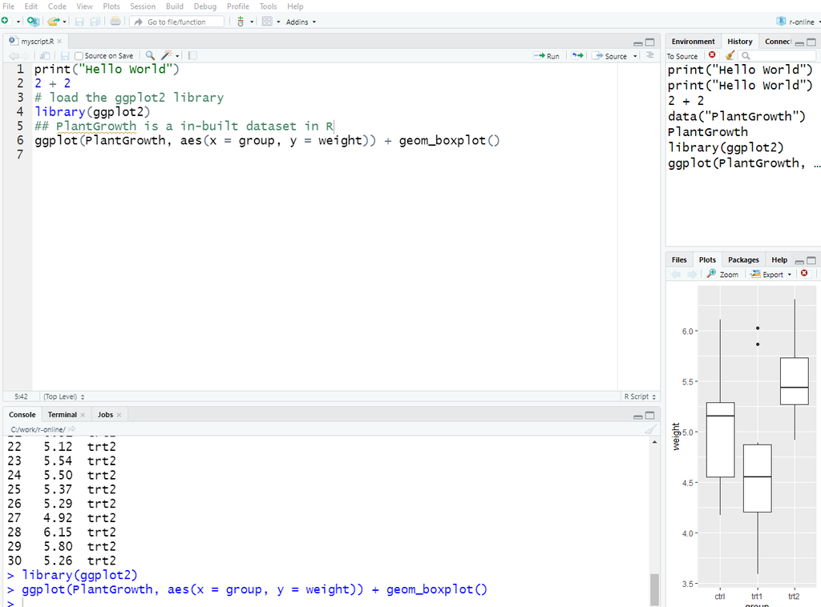

There is a limited ability to add explanations and commentary to the file via the use of comments; e.g. lines 3 and 5 in the screenshot that have a `#` at the start of the line. Rstudio formats the text for the comments in green.

The output of each line of code appears in the console, and any plots generated appear in the bottom-right panel. It is a step in the right direction, but far from a report that we can distribute to our peers. In order to make a report we would have to (manually) export the plots from RStudio and copy into another document or presentation. If the underlying data change, this becomes problematic; as illustrated in the following video

[A non reproducible workflow](https://youtu.be/s3JldKoA0zw) - 2 minutes

## An R markdown file

An R markdown file solves the problem described above whereby plots, tables and statistics generated during the course of the analysis have to be manually copied into a report document. This process lends itself to errors and uncertainty over whether the latest version of the data are being used in the analysis.

You can think of the R markdown as a template used to create a report; which can be in Word, PDF or HTML formats (creating PDF will require you to have the latex typesetting program installed). The language used to create the report is *markdown* which is a popular typesetting language. The screenshot below shows an example markdown file to analyse the `PlantGrowth` dataset, which is a dataset available through R.

[figure not shown]

Lines 1 - 4 are “header” information that is used to give a title for your report and specify what format the report will be generated in.

Line 6 is an example the text formatting that is possible in markdown. Here “Introduction” will appear as a level 1 heading in the final report.

Lines 10 to 15 are an **R code chunk**. Lines 10 and 15 show where the “chunk” begins and ends, and anything in-between will be interpreted as R code. The code can be run by either highlighting particular lines and pressing CTRL+Enter, or hitting the green play button in the top-right of the chunk. The results appear directly underneath.

At any point you can see what your report will look like by pressing the **Knit** button. At this point all the R code in the document is run in sequence. Provided there are no errors in your code, a pop-up window should appear. It advisable to knit the report early and often.

[figure not shown]

We will typically use Markdown to create report documents, but in fact the same format can be used to generate a wide range of outputs; including web pages (the web pages for this course were all generated in R markdown), and presentations.

## An R notebook

An R notebook is a variation of the R markdown file and similar in most respects. The key different is how the report is generated. With an R markdown file all the code has to be run in order to generate the report. However with an R notebook it merely displayed the output of the code that you have run.

## Markdown formating and Chunk options

Anything inside an R code chunk is executed as R code, whereas anything outside is rendered as text. However, rather than plain boring text we can add all manner of formatting options to add emphasis such as *italics* or **bold** by adding `*` or `**` around the text. We can also add weblinks, images and lists. A quick summary is available through the RStudio Help menu.

Help -> Markdown Quick Reference

We can also controls aspects of how the R code is executed and displayed in the final report. This is achieved by adding extra options to the first line of the code chunk; the one with the `{r}`. Multiple options can be used by putting a `,` in between each one.

### eval

`{r eval=FALSE}`

We might not actually want to run the code inside the chunk, which we can do by specifying `eval=FALSE`. The effect on the final report is that the code is displayed but not actually run. For example, you might want to remind you reader of the code to install a particular package, but not actually run that code every time the report is generated.

Or you might want to show the code you have used to import a large file from disk, but not have the code executed each time.

### echo

`{r echo=FALSE}`

The opposite is `echo` which runs a chunk of code, but doesn’t print the code itself. For example you might to setup some parameters or load some pre-processed. files from disk

### `warning` and `message`

`{r warning=FALSE, message=FALSE}`

This stops any warnings or messages from being printed to the report. These can occur when a package is loaded, but might not be of interest to anyone reading the report

## In-line R code

When writing a commentary to accompany your analysis you might have to refer to specific results you have calculated. e.g. for RNA-seq the p-values or fold-changes of particular genes of interest. Rather than having to manually type the values each time (which can change if we tweak our parameters), we can insert R code within our text to retrieve the value of a particular variable.

```r
## for demonstration only.
p <- 0.05
fc <- 2.35
```

Using a single *backtick* allows R code to be evaluated. Here we print the values of `p` and `fc` from our environment.

```
the p-value for Gene X is `r p` with a fold-change of `r fc`
```

The text would be rendered thus. So if the value of `p` and `fc` change the text would automatically update.

the p-value for Gene X is 0.05 with a fold-change of 2.35

### Exercise

- Create an R notebook file to read the file `gapminder_pre2007.csv` into R and produce a scatter plot of `gdpPercap` versus `lifeExp` (as we did in the introductory R course).
- Make sure that you can preview your report and create a HTML file.
- Now imagine that the dataset has now been updated to include 2007 metrics (file `gapminder.csv`). Update your report to read the full dataset and create a new report

# The role of Bioconductor in reproducible research

The bioconductor project has been instrumental in distributing software for the analysis of high-throughput biological data since the early 2000s. The initial set of packages were focused on the analysis of microarray data, but the set of packages has expanded to include sequencing data of various forms along with proteomics, flow cytometry and image analysis. Packages in Bioconductor are generally of high-quality as researchers have to pass a number of rigourous set of test before the software can be distributed.

The documentation standards are also higher than other R repositories. Each package is required to have a user guide (or vignette) that describes in detail how to perform analyses with the package and present several use cases.

### Exercise

- Go to the Bioconductor website and navigate to the list of software packages. How many packages are available for the analysis of RNA-seq data? What are the top five most popular packages?
- Who is the maintainer of the `DESeq2` package? What is the latest version and when was the *user guide* last updated?
- Back on the software packages page, how many *workflows* are available for GeneExpression?
- How many example RNA-seq datasets are available via the *ExperimentData* section?

# Summary

- R markdown notebooks can facilitate reproducible research
- Reports created from an R notebook can be shared with our peers who can see the code we used and run for themselves.
- The Bioconductor project distributes software, workflows, annotation and example datasets
- Help on a particular package can be obtained via it’s user guide, or from the support forum.

# Exercise for next time

Install the following set of packages that are available through Bioconductor.

- `DESeq2`, `pheatmap`, `org.Mm.eg.db`. `genefilter`